# STA302 Final Project

## 1. Data Import & Cleaning

We start by loading the raw NBA data and inspecting its first rows.

```r
# Read nba_final.csv
nba <- read.csv("nba_final.csv", stringsAsFactors = FALSE)
head(nba)
```

```
##    Rk        Player.x Player_ID Pos1 Pos2 Age  Tm  G GS   MP  FG  FGA   FG. X3P
## 1 170    A.J. Hammons hammoaj01    C <NA>  24 DAL 22  0  7.4 0.8  1.9 0.405 0.2
## 2  58    Aaron Brooks brookaa01   PG <NA>  32 IND 65  0 13.8 1.9  4.6 0.403 0.7
## 3 157    Aaron Gordon gordoaa01   SF <NA>  21 ORL 80 72 28.7 4.9 10.8 0.454 1.0
## 4 352   Adreian Payne paynead01   PF <NA>  25 MIN 18  0  7.5 1.3  3.0 0.426 0.2
## 5  10 Al-Farouq Aminu aminual01   PF <NA>  26 POR 61 25 29.1 3.0  7.6 0.393 1.1
## 6 203      Al Horford horfoal01    C <NA>  30 BOS 68 68 32.3 5.6 11.8 0.473 1.3
##   X3PA  X3P. X2P X2PA  X2P.  eFG.  FT FTA   FT. ORB DRB TRB AST STL BLK TOV  PF
## 1  0.5 0.500 0.5  1.5 0.375 0.464 0.4 0.9 0.450 0.4 1.3 1.6 0.2 0.0 0.6 0.5 1.0
## 2  2.0 0.375 1.1  2.6 0.424 0.483 0.5 0.6 0.800 0.3 0.8 1.1 1.9 0.4 0.1 1.0 1.4
## 3  3.3 0.288 4.0  7.5 0.528 0.499 2.0 2.7 0.719 1.5 3.6 5.1 1.9 0.8 0.5 1.1 2.2
## 4  0.8 0.200 1.1  2.2 0.513 0.454 0.8 1.1 0.737 0.5 1.3 1.8 0.4 0.4 0.4 0.4 1.8
## 5  3.5 0.330 1.9  4.2 0.445 0.468 1.6 2.2 0.706 1.3 6.1 7.4 1.6 1.0 0.7 1.5 1.7
## 6  3.6 0.355 4.3  8.2 0.524 0.527 1.6 2.0 0.800 1.4 5.4 6.8 5.0 0.8 1.3 1.7 2.0
##    PTS   Salary mean_views  Season Conference  Role  Fvot FRank Pvot PRank Mvot
## 1  2.2       NA    3.32000 2016-17       West Front   786   123   NA    NA   NA
## 2  5.0  2700000   11.15574 2016-17        Est  Back  2474    64   NA    NA   NA
## 3 12.7  4351320 1713.98634 2016-17        Est Front 22774    29   NA    NA   NA
## 4  3.5  2022240  205.85519 2016-17       West Front   861   120    1    52   NA
## 5  8.7  7680965  604.34153 2016-17       West Front  4971    69    7    23   NA
## 6 14.0 26540100 1556.38251 2016-17        Est Front 12219    14    8    16    2
##   MRank Score Play
## 1    NA  83.5   No
## 2    NA  48.2   No
## 3    NA  40.0   No
## 4    NA  75.5   No
## 5    NA  42.8   No
## 6     6  12.5   No
```

```
## Initial sample size (n): 1408
```

Next, we compute a table showing how many NAs each variable has.

```r
# Compute missing data summary table
missing_summary <- data.frame(
  Variable = names(nba),
  Missing_Count = sapply(nba, function(x) sum(is.na(x))),
  Total_Count = nrow(nba)
)
missing_summary$Missing_Percent <- round(100 * missing_summary$Missing_Count / missing_summary$Total_Count, 2)
missing_summary <- missing_summary[missing_summary$Missing_Count > 0, ]
missing_summary <- missing_summary[order(-missing_summary$Missing_Count), ]

# Print the missing data summary
knitr::kable(missing_summary, caption = "Missing Data Summary (sorted by count)")
```

Missing Data Summary (sorted by count)

|  | Variable | Missing_Count | Total_Count | Missing_Percent |
| --- | --- | --- | --- | --- |
| Pos2 | Pos2 | 1396 | 1408 | 99.15 |
| Mvot | Mvot | 404 | 1408 | 28.69 |
| MRank | MRank | 404 | 1408 | 28.69 |
| Pvot | Pvot | 159 | 1408 | 11.29 |
| PRank | PRank | 159 | 1408 | 11.29 |
| mean_views | mean_views | 138 | 1408 | 9.80 |
| X3P. | X3P. | 99 | 1408 | 7.03 |
| Salary | Salary | 62 | 1408 | 4.40 |
| FT. | FT. | 47 | 1408 | 3.34 |
| X2P. | X2P. | 15 | 1408 | 1.07 |
| FG. | FG. | 4 | 1408 | 0.28 |
| eFG. | eFG. | 4 | 1408 | 0.28 |

We found that Pos2 had too many missing values (99.15%), so we dropped it. We also removed 62 rows (4.40%) with missing Salary values, but kept all other variables since they had reasonable amounts of missing data (≤ 28.69%).

```r
# Check for missing values using base R
missing_cols <- colSums(is.na(nba))

# Drop variables with > 90% missing values
missing_threshold <- 0.9 * nrow(nba)
high_missing_cols <- names(missing_cols[missing_cols > missing_threshold])
cat("Columns with >90% missing values:", paste(high_missing_cols, collapse=", "), "\n")
```

```
## Columns with >90% missing values: Pos2
```

```r
if (length(high_missing_cols) > 0) {
  nba <- nba[, !names(nba) %in% high_missing_cols]
}

# Convert categorical variables to factors
nba$Pos1 <- as.factor(nba$Pos1)
nba$Conference <- as.factor(nba$Conference)
nba$Role <- as.factor(nba$Role)
nba$Play <- as.factor(nba$Play)

# Remove rows with missing Salary
nba <- nba[!is.na(nba$Salary), ]

# Show table of remaining NAs and a glimpse summary
remaining_nas <- colSums(is.na(nba))
na_df <- data.frame(
  Variable = names(remaining_nas[remaining_nas > 0]),
  Missing_Count = remaining_nas[remaining_nas > 0],
  Percentage = round(100 * remaining_nas[remaining_nas > 0] / nrow(nba), 2)
)
knitr::kable(na_df, caption = "Remaining missing values")
```

Remaining missing values

|  | Variable | Missing_Count | Percentage |
| --- | --- | --- | --- |
| FG. | FG. | 4 | 0.30 |
| X3P. | X3P. | 97 | 7.21 |
| X2P. | X2P. | 13 | 0.97 |
| eFG. | eFG. | 4 | 0.30 |
| FT. | FT. | 43 | 3.19 |
| mean_views | mean_views | 127 | 9.44 |
| Pvot | Pvot | 149 | 11.07 |
| PRank | PRank | 149 | 11.07 |
| Mvot | Mvot | 383 | 28.45 |
| MRank | MRank | 383 | 28.45 |

```r
# Glimpse of the data using dplyr
glimpse(nba)
```

```
## Rows: 1,346
## Columns: 44
## $ Rk         <int> 58, 157, 352, 10, 203, 221, 12, 464, 65, 1, 260, 5, 92, 149…
## $ Player.x   <chr> "Aaron Brooks", "Aaron Gordon", "Adreian Payne", "Al-Farouq…
## $ Player_ID  <chr> "brookaa01", "gordoaa01", "paynead01", "aminual01", "horfoa…
## $ Pos1       <fct> PG, SF, PF, PF, C, C, SF, C, SG, SG, C, C, SG, SF, PF, C, C…
## $ Age        <int> 32, 21, 25, 26, 30, 32, 34, 24, 25, 23, 23, 28, 24, 29, 29,…
## $ Tm         <chr> "IND", "ORL", "MIN", "POR", "BOS", "IND", "LAC", "PHO", "UT…
## $ G          <int> 65, 80, 18, 61, 68, 66, 30, 47, 42, 68, 77, 39, 79, 13, 80,…
## $ GS         <int> 0, 72, 0, 25, 68, 1, 0, 0, 0, 6, 34, 15, 7, 0, 77, 1, 81, 0…
## $ MP         <dbl> 13.8, 28.7, 7.5, 29.1, 32.3, 14.1, 10.3, 15.1, 15.5, 15.5, …
## $ FG         <dbl> 1.9, 4.9, 1.3, 3.0, 5.6, 3.6, 1.0, 2.9, 2.4, 2.0, 3.0, 2.3,…
## $ FGA        <dbl> 4.6, 10.8, 3.0, 7.6, 11.8, 7.1, 2.7, 5.7, 5.9, 5.0, 6.0, 4.…
## $ FG.        <dbl> 0.403, 0.454, 0.426, 0.393, 0.473, 0.499, 0.375, 0.517, 0.3…
## $ X3P        <dbl> 0.7, 1.0, 0.2, 1.1, 1.3, 0.0, 0.5, 0.0, 0.6, 1.4, 0.0, 0.0,…
```

[output cut: 31 more lines]

## 2. Exploratory Analysis

Let’s first look at the distribution of player salaries.

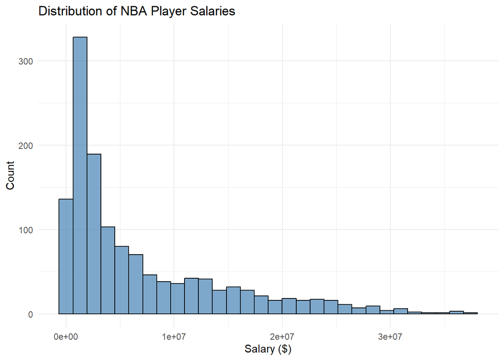

```r
# Histogram of Salary
ggplot(nba, aes(x = Salary)) +
  geom_histogram(bins = 30, fill = "steelblue", color = "black", alpha = 0.7) +
  labs(title = "Distribution of NBA Player Salaries", x = "Salary ($)", y = "Count") +
  theme_minimal()
```

To get a quick overview of relationships between variables, we create a scatterplot matrix of our core numeric variables.

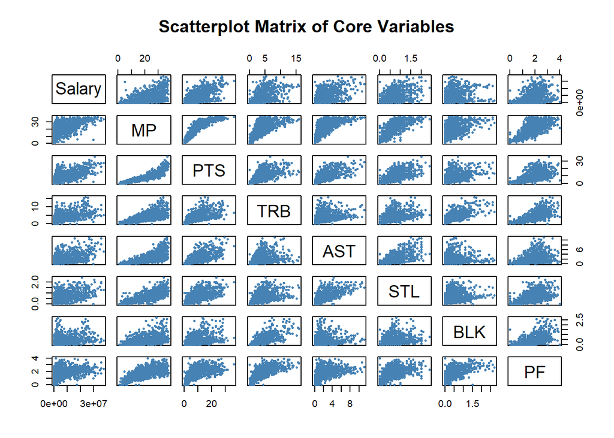

```r
# Create pairs scatterplot matrix of core numeric variables
core_vars <- c("Salary", "MP", "PTS", "TRB", "AST", "STL", "BLK", "PF")
core_vars <- core_vars[core_vars %in% names(nba)]
pairs(nba[, core_vars],
      main = "Scatterplot Matrix of Core Variables",
      pch = 16,
      col = "steelblue",
      cex = 0.5)
```

We want to examine how each key stat relates to player salary, so we create individual scatterplots with trend lines.

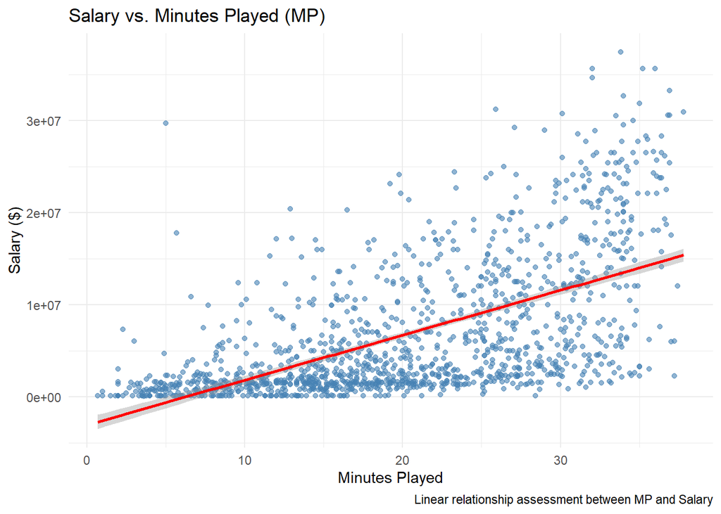

```r
# Scatterplots of Salary vs core stats
# MP
ggplot(nba, aes(x = MP, y = Salary)) +
  geom_point(alpha = 0.6, color = "steelblue") +
  geom_smooth(method = "lm", color = "red") +
  labs(title = "Salary vs. Minutes Played (MP)",
       x = "Minutes Played",
       y = "Salary ($)",
       caption = "Linear relationship assessment between MP and Salary") +
  theme_minimal()
```

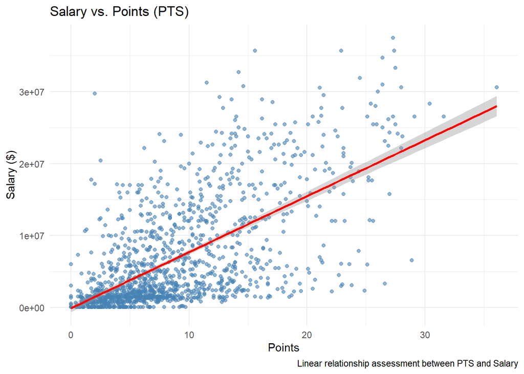

```r
# PTS
ggplot(nba, aes(x = PTS, y = Salary)) +
  geom_point(alpha = 0.6, color = "steelblue") +
  geom_smooth(method = "lm", color = "red") +
  labs(title = "Salary vs. Points (PTS)",
       x = "Points",
       y = "Salary ($)",
       caption = "Linear relationship assessment between PTS and Salary") +
  theme_minimal()
```

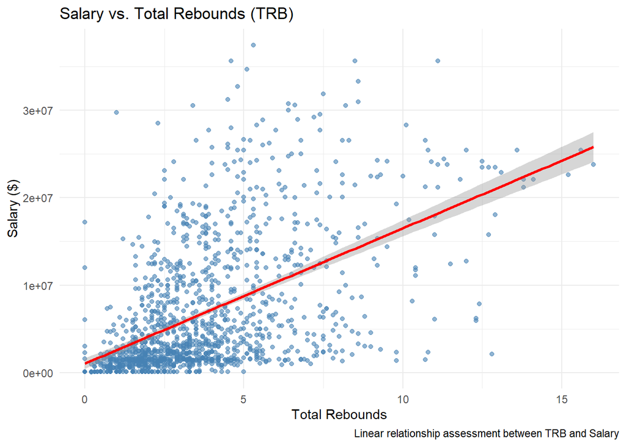

```r
# TRB
ggplot(nba, aes(x = TRB, y = Salary)) +
  geom_point(alpha = 0.6, color = "steelblue") +
  geom_smooth(method = "lm", color = "red") +
  labs(title = "Salary vs. Total Rebounds (TRB)",
       x = "Total Rebounds",
       y = "Salary ($)",
       caption = "Linear relationship assessment between TRB and Salary") +
  theme_minimal()
```

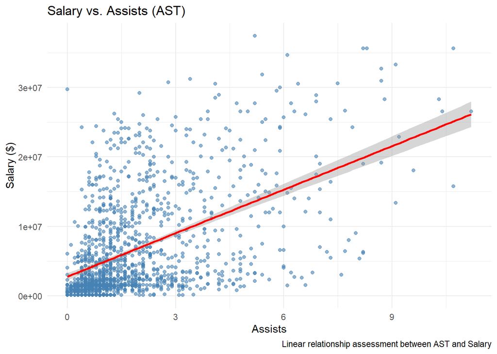

```r
# AST
ggplot(nba, aes(x = AST, y = Salary)) +
  geom_point(alpha = 0.6, color = "steelblue") +
  geom_smooth(method = "lm", color = "red") +
  labs(title = "Salary vs. Assists (AST)",
       x = "Assists",
       y = "Salary ($)",
       caption = "Linear relationship assessment between AST and Salary") +
  theme_minimal()
```

To check for potential multicollinearity, we create a correlation heatmap and table.

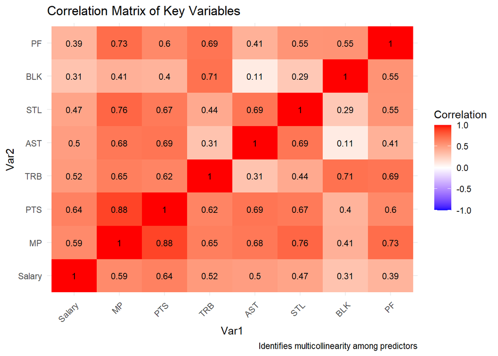

```r
# Correlation matrix/heatmap using ggplot2
cor_vars <- c("Salary", "MP", "PTS", "TRB", "AST", "STL", "BLK", "PF")
cor_vars <- cor_vars[cor_vars %in% names(nba)]

# Calculate correlation matrix (handling NAs)
cor_matrix <- cor(nba[, cor_vars], use = "pairwise.complete.obs")

# Convert to tidy data format for ggplot
cor_tidy <- as.data.frame(as.table(cor_matrix))
names(cor_tidy) <- c("Var1", "Var2", "Correlation")

# Create correlation heatmap with ggplot2
ggplot(cor_tidy, aes(x = Var1, y = Var2, fill = Correlation)) +
  geom_tile() +
  scale_fill_gradient2(low = "blue", high = "red", mid = "white",
                       midpoint = 0, limit = c(-1,1)) +
  geom_text(aes(label = round(Correlation, 2)), color = "black", size = 3) +
  theme_minimal() +
  labs(title = "Correlation Matrix of Key Variables",
       caption = "Identifies multicollinearity among predictors") +
  theme(axis.text.x = element_text(angle = 45, hjust = 1))
```

```r
# Also create a correlation table
knitr::kable(round(cor_matrix, 2), caption = "Correlation Matrix")
```

Correlation Matrix

|  | Salary | MP | PTS | TRB | AST | STL | BLK | PF |
| --- | --- | --- | --- | --- | --- | --- | --- | --- |
| Salary | 1.00 | 0.59 | 0.64 | 0.52 | 0.50 | 0.47 | 0.31 | 0.39 |
| MP | 0.59 | 1.00 | 0.88 | 0.65 | 0.68 | 0.76 | 0.41 | 0.73 |
| PTS | 0.64 | 0.88 | 1.00 | 0.62 | 0.69 | 0.67 | 0.40 | 0.60 |
| TRB | 0.52 | 0.65 | 0.62 | 1.00 | 0.31 | 0.44 | 0.71 | 0.69 |
| AST | 0.50 | 0.68 | 0.69 | 0.31 | 1.00 | 0.69 | 0.11 | 0.41 |
| STL | 0.47 | 0.76 | 0.67 | 0.44 | 0.69 | 1.00 | 0.29 | 0.55 |
| BLK | 0.31 | 0.41 | 0.40 | 0.71 | 0.11 | 0.29 | 1.00 | 0.55 |
| PF | 0.39 | 0.73 | 0.60 | 0.69 | 0.41 | 0.55 | 0.55 | 1.00 |

Our correlation analysis revealed some concerning relationships. Minutes Played (MP) is strongly correlated with Points (PTS) at r = 0.88 and with Steals (STL) at r = 0.76. These high correlations could cause multicollinearity problems in our models, which is why we’ll use mean-centering in the next section.

## 3. Transformations & Diagnostics

```r
# 1. Fit raw (un-transformed) model
mod_raw <- lm(
  Salary ~ MP + PTS + TRB + AST + STL + BLK + PF + Play,
  data = nba
)
summary(mod_raw)
```

```
##
## Call:
## lm(formula = Salary ~ MP + PTS + TRB + AST + STL + BLK + PF +
##     Play, data = nba)
##
## Residuals:
##       Min        1Q    Median        3Q       Max
## -17879418  -3287179   -869343   2590166  29586682
##
## Coefficients:
##             Estimate Std. Error t value Pr(>|t|)
## (Intercept)  -512671     422130  -1.214 0.224777
## MP            164655      47341   3.478 0.000521 ***
## PTS           257172      63014   4.081 4.75e-05 ***
## TRB           889093     106402   8.356  < 2e-16 ***
## AST           564201     134762   4.187 3.02e-05 ***
## STL           -62157     592255  -0.105 0.916432
## BLK          -407170     536904  -0.758 0.448365
## PF          -1572820     334964  -4.695 2.93e-06 ***
## PlayYes      4514685     863866   5.226 2.01e-07 ***
## ---
## Signif. codes:  0 '***' 0.001 '**' 0.01 '*' 0.05 '.' 0.1 ' ' 1
##
## Residual standard error: 5445000 on 1337 degrees of freedom
## Multiple R-squared:  0.4693, Adjusted R-squared:  0.4661
## F-statistic: 147.8 on 8 and 1337 DF,  p-value: < 2.2e-16
```

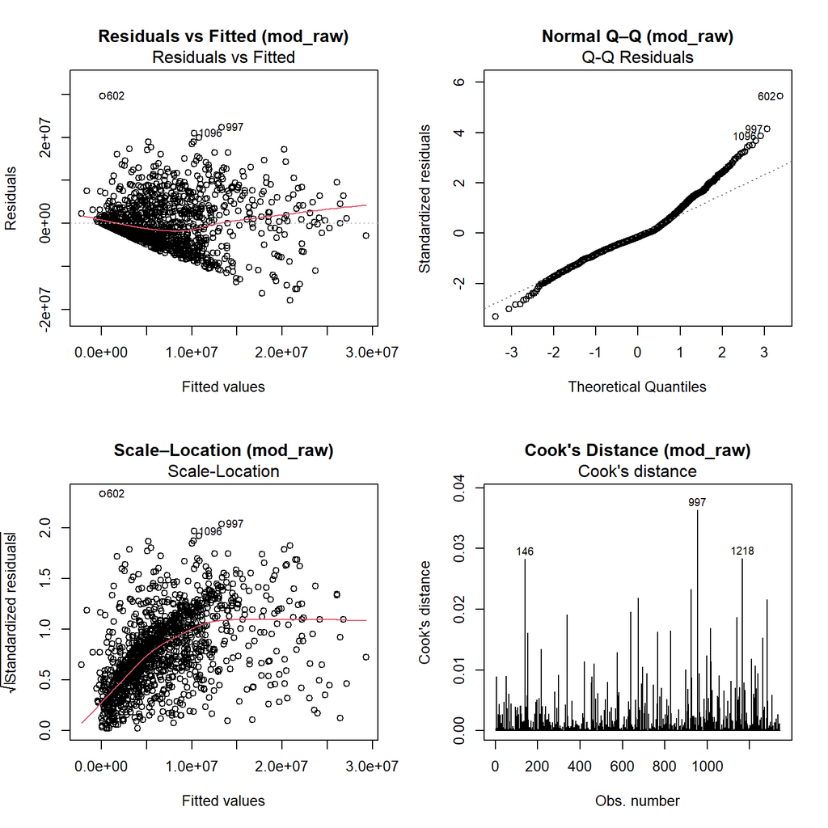

First, we apply the Box-Cox procedure to find the optimal transformation for Salary.

```r
# Run Box-Cox on Salary ~ core stats
bc_model <- lm(Salary ~ MP + PTS + TRB + AST + STL + BLK + PF + Play, data = nba)
bc_result <- MASS::boxcox(bc_model, plotit=FALSE)
lambda <- bc_result$x[which.max(bc_result$y)]
cat("Optimal Box-Cox lambda:", lambda, "\n")
```

```
## Optimal Box-Cox lambda: 0.2
```

```r
# Create log10(Salary) if lambda ≈ 0
nba$logSalary <- log10(nba$Salary)
```

```r
# Center numeric predictors first
nba$MP_c <- scale(nba$MP, center = TRUE, scale = FALSE)
nba$PTS_c <- scale(nba$PTS, center = TRUE, scale = FALSE)
nba$TRB_c <- scale(nba$TRB, center = TRUE, scale = FALSE)
nba$AST_c <- scale(nba$AST, center = TRUE, scale = FALSE)
nba$STL_c <- scale(nba$STL, center = TRUE, scale = FALSE)
nba$BLK_c <- scale(nba$BLK, center = TRUE, scale = FALSE)

# Create additional terms
nba$MP_c2 <- nba$MP_c^2
nba$MP_c_PTS_c <- nba$MP_c * nba$PTS_c
nba$MP_c_AST_c <- nba$MP_c * nba$AST_c
```

```r
# 2. Fit log10-transformed model
mod_init <- lm(
  log10(Salary) ~ MP_c + PTS_c + TRB_c + AST_c + STL_c + BLK_c + Play,
  data = nba
)
summary(mod_init)
```

```
##
## Call:
## lm(formula = log10(Salary) ~ MP_c + PTS_c + TRB_c + AST_c + STL_c +
##     BLK_c + Play, data = nba)
##
## Residuals:
##      Min       1Q   Median       3Q      Max
## -1.88291 -0.26054  0.06279  0.32544  1.62192
##
## Coefficients:
##              Estimate Std. Error t value Pr(>|t|)
## (Intercept)  6.498076   0.013878 468.216  < 2e-16 ***
## MP_c         0.035123   0.003936   8.925  < 2e-16 ***
## PTS_c        0.001075   0.005585   0.193    0.847
## TRB_c        0.043391   0.009148   4.743 2.33e-06 ***
## AST_c        0.018329   0.012023   1.524    0.128
## STL_c       -0.058404   0.052800  -1.106    0.269
## BLK_c       -0.026231   0.046917  -0.559    0.576
## PlayYes      0.106525   0.076502   1.392    0.164
## ---
## Signif. codes:  0 '***' 0.001 '**' 0.01 '*' 0.05 '.' 0.1 ' ' 1
##
## Residual standard error: 0.4859 on 1338 degrees of freedom
## Multiple R-squared:  0.4196, Adjusted R-squared:  0.4166
## F-statistic: 138.2 on 7 and 1338 DF,  p-value: < 2.2e-16
```

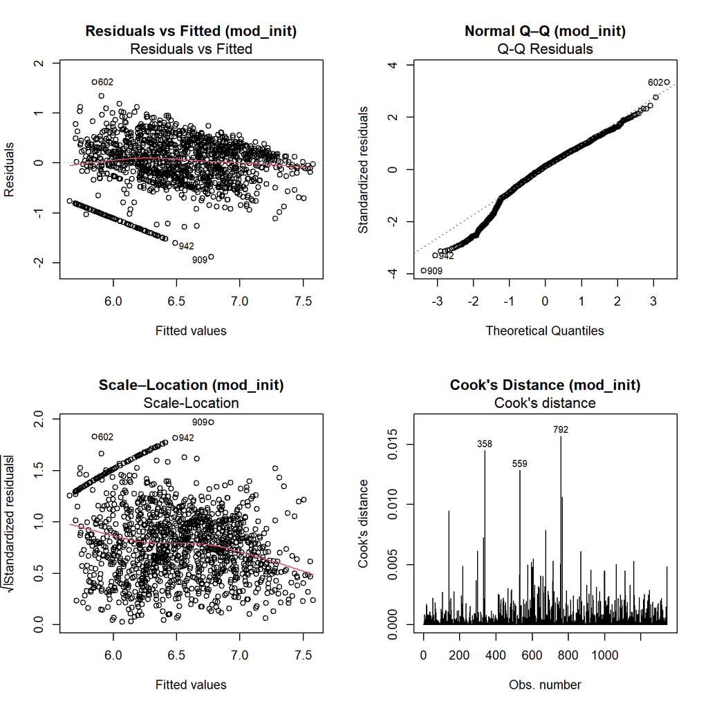

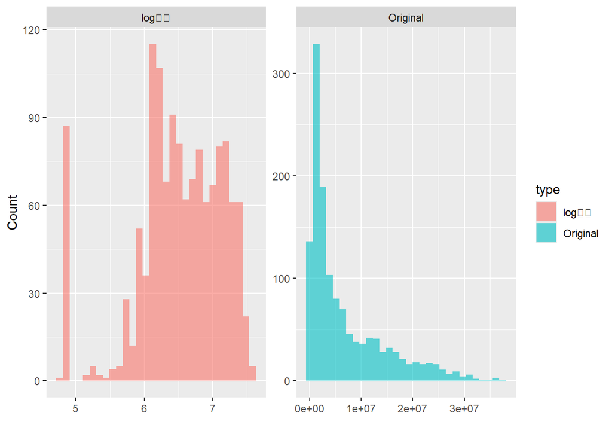

Original vs log₁₀(Salary) distributions

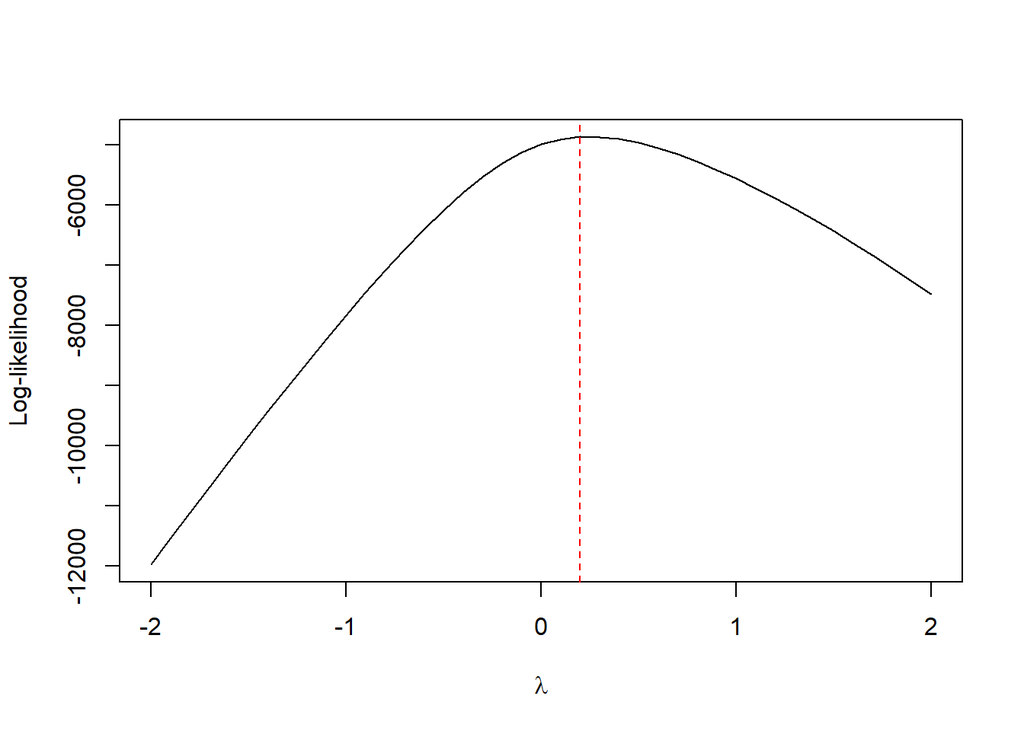

Box–Cox log-likelihood vs λ

Next, we already centered our predictors and created interaction terms to reduce multicollinearity.

We centered all our core stats (MP, PTS, TRB, AST, STL, BLK) to reduce multicollinearity. We also added a squared term for Minutes Played and two interaction terms to capture potential non-linear relationships.

Let’s compare the original and transformed salary distributions.

Now we fit our initial model using the centered predictors and transformed response.

```r
# Fit mod_init
mod_init <- lm(logSalary ~ MP_c + PTS_c + TRB_c + AST_c + STL_c + BLK_c + Play, data = nba)
summary(mod_init)
```

```
##
## Call:
## lm(formula = logSalary ~ MP_c + PTS_c + TRB_c + AST_c + STL_c +
##     BLK_c + Play, data = nba)
##
## Residuals:
##      Min       1Q   Median       3Q      Max
## -1.88291 -0.26054  0.06279  0.32544  1.62192
##
## Coefficients:
##              Estimate Std. Error t value Pr(>|t|)
## (Intercept)  6.498076   0.013878 468.216  < 2e-16 ***
## MP_c         0.035123   0.003936   8.925  < 2e-16 ***
## PTS_c        0.001075   0.005585   0.193    0.847
## TRB_c        0.043391   0.009148   4.743 2.33e-06 ***
## AST_c        0.018329   0.012023   1.524    0.128
## STL_c       -0.058404   0.052800  -1.106    0.269
## BLK_c       -0.026231   0.046917  -0.559    0.576
## PlayYes      0.106525   0.076502   1.392    0.164
## ---
## Signif. codes:  0 '***' 0.001 '**' 0.01 '*' 0.05 '.' 0.1 ' ' 1
##
## Residual standard error: 0.4859 on 1338 degrees of freedom
## Multiple R-squared:  0.4196, Adjusted R-squared:  0.4166
## F-statistic: 138.2 on 7 and 1338 DF,  p-value: < 2.2e-16
```

```
## Leverage cutoff: 0.0119 — Obs above cutoff: 162
```

mod_init coefficients (95% CI)

| term | estimate | std.error | statistic | p.value | conf.low | conf.high |
| --- | --- | --- | --- | --- | --- | --- |
| (Intercept) | 6.4980762 | 0.0138784 | 468.2162467 | 0.0000000 | 6.4708505 | 6.5253019 |
| MP_c | 0.0351230 | 0.0039355 | 8.9245882 | 0.0000000 | 0.0274025 | 0.0428435 |
| PTS_c | 0.0010752 | 0.0055851 | 0.1925157 | 0.8473675 | -0.0098812 | 0.0120316 |
| TRB_c | 0.0433909 | 0.0091478 | 4.7433253 | 0.0000023 | 0.0254453 | 0.0613364 |
| AST_c | 0.0183293 | 0.0120233 | 1.5244881 | 0.1276231 | -0.0052572 | 0.0419158 |
| STL_c | -0.0584038 | 0.0528002 | -1.1061297 | 0.2688692 | -0.1619840 | 0.0451763 |
| BLK_c | -0.0262310 | 0.0469167 | -0.5590980 | 0.5761884 | -0.1182693 | 0.0658072 |
| PlayYes | 0.1065254 | 0.0765019 | 1.3924558 | 0.1640158 | -0.0435512 | 0.2566021 |

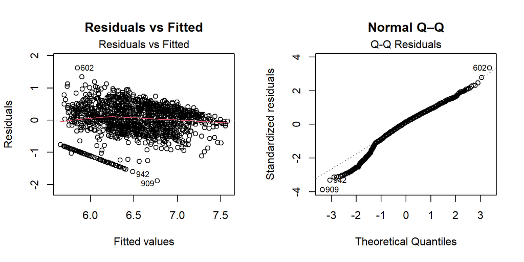

Residuals vs Fitted & Normal Q–Q

Our initial model shows that several predictors (PTS_c, AST_c, STL_c, BLK_c, PlayYes) aren’t significant at the 0.05 level. We’ll keep them in our models anyway because they’re important basketball metrics.

Let’s check for multicollinearity using Variance Inflation Factors (VIF).

```r
# VIF table
vif_values <- vif(mod_init)
knitr::kable(data.frame(
  Variable = names(vif_values),
  VIF = vif_values
), caption = "Variance Inflation Factors - Check for multicollinearity")
```

Variance Inflation Factors - Check for multicollinearity

|  | Variable | VIF |
| --- | --- | --- |
| MP_c | MP_c | 7.264200 |
| PTS_c | PTS_c | 6.649259 |
| TRB_c | TRB_c | 2.999263 |
| AST_c | AST_c | 2.644667 |
| STL_c | STL_c | 2.757831 |
| BLK_c | BLK_c | 2.079750 |
| Play | Play | 1.711550 |

Our VIF analysis shows moderate collinearity for MP_c (7.26) and PTS_c (6.65), but they’re below our threshold of 10. However, we found that in our interaction model, the MP_c×PTS_c term has a VIF of 11.69, which is too high. This warns us against over-complicating our model.

Next, we examine residual plots to check model assumptions.

```r
# Residual plots for heteroskedasticity and normality checks
# We already have diagnostic plots earlier in the document

# Store fitted values and residuals for later use
fitted_values <- fitted(mod_init)
residuals <- residuals(mod_init)
```

We also create component-plus-residual plots to check for linearity in each predictor’s relationship with the response.

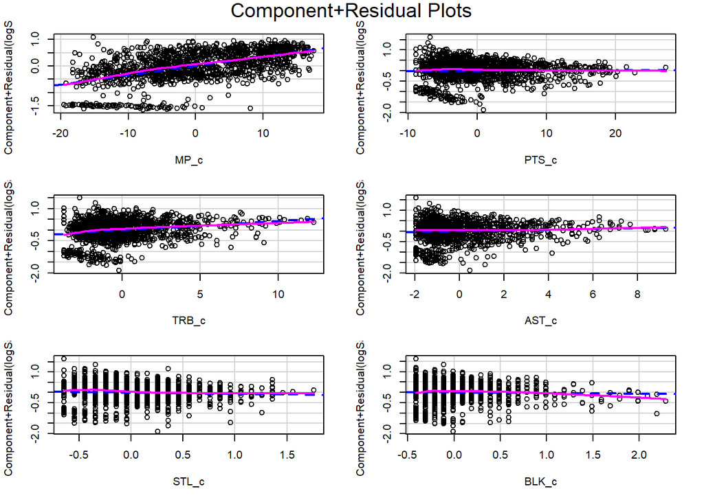

```r
# Component+Residual plots for checking linearity assumptions
crPlots(mod_init, terms = ~ MP_c + PTS_c + TRB_c + AST_c + STL_c + BLK_c,
        main = "Component+Residual Plots",
        caption = "Check for linearity in the relationship between each predictor and response")
```

To understand each predictor’s effect while controlling for others, we create added-variable plots.

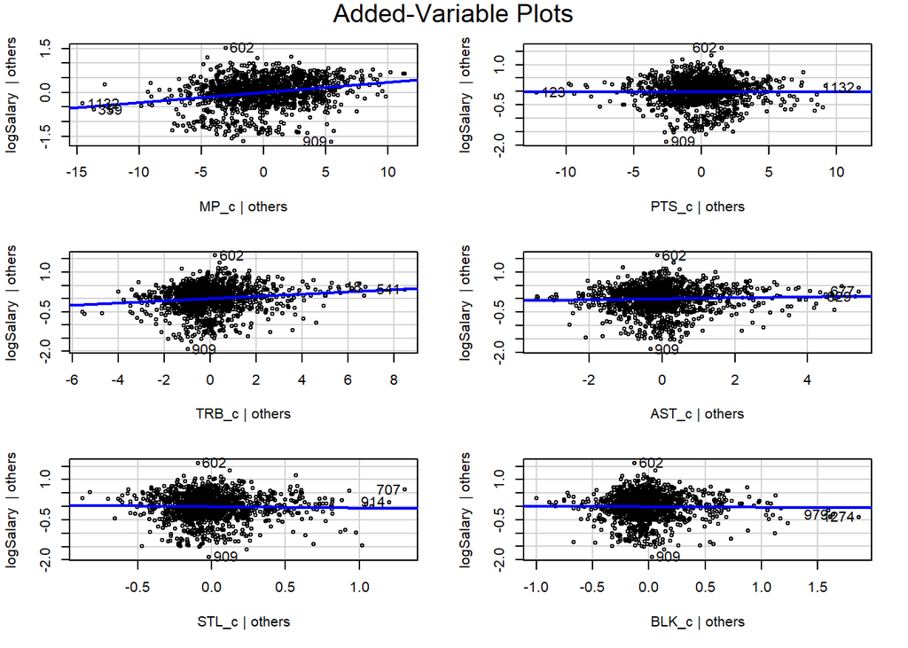

```r
# Added-Variable plots to visualize each predictor's partial effect
avPlots(mod_init, terms = ~ MP_c + PTS_c + TRB_c + AST_c + STL_c + BLK_c,
        main = "Added-Variable Plots",
        caption = "Visualize partial effects of each predictor controlling for others")
```

Finally, we identify influential observations using Cook’s distance.

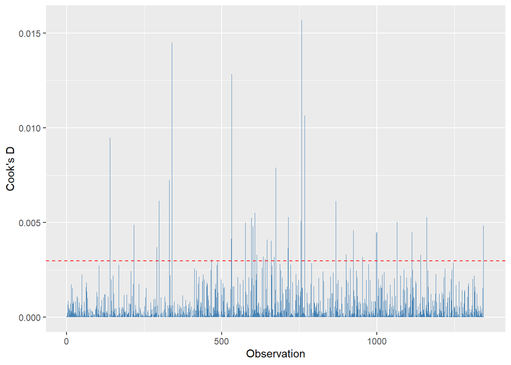

Cook’s distance for mod_init

[output not shown]

```
## Found 37 influential observations (Cook's D > 0.003 )
```

```r
# Calculate Cook's distance
cooksd <- cooks.distance(mod_init)
cutoff <- 4/nrow(nba)

# Create a data frame for plotting
cooksd_df <- data.frame(
  obs = 1:length(cooksd),
  cooksd = cooksd
)
```

```r
# Create table of top 10 influential observations
top_infl <- head(sort(cooksd, decreasing = TRUE), 10)
infl_df <- data.frame(
  Observation = as.integer(names(top_infl)),
  Cooks_Distance = top_infl,
  Std_Residual = rstandard(mod_init)[as.integer(names(top_infl))],
  Leverage = hatvalues(mod_init)[as.integer(names(top_infl))]
)
knitr::kable(infl_df, caption = "Top 10 influential observations")
```

Top 10 influential observations

|  | Observation | Cooks_Distance | Std_Residual | Leverage |
| --- | --- | --- | --- | --- |
| 792 | 792 | 0.0156751 | 0.5519586 | 0.0025889 |
| 358 | 358 | 0.0144893 | 0.5226175 | 0.0076506 |
| 559 | 559 | 0.0128385 | 0.0763531 | 0.0041708 |
| 803 | 803 | 0.0106449 | 0.7683613 | 0.0066990 |
| 146 | 146 | 0.0094798 | 0.5267226 | 0.0099510 |
| 707 | 707 | 0.0078863 | -0.7373519 | 0.0184738 |
| 349 | 349 | 0.0072410 | 0.2556458 | 0.0117652 |
| 706 | 706 | 0.0064303 | -1.8959051 | 0.0032524 |
| 315 | 315 | 0.0061506 | 0.9296039 | 0.0017488 |
| 909 | 909 | 0.0061266 | 0.5297077 | 0.0020614 |

```r
# Create nba_clean dataset
nba_clean <- nba[-infl_obs, ]
```

Our diagnostics identified 37 influential observations with Cook’s D > 4/n (0.003). We removed these to create our nba_clean dataset, which we’ll use for our “clean” models. Earlier, we also dropped the Pos2 variable entirely since over 99% of its values were missing.

## 4. Model Building & Comparison

First, we define functions for cross-validation and model comparison.

```r
# Define CV-MSE function
cv_mse <- function(model, data, k = 10) {
  set.seed(123)  # For reproducibility

  # Extract model formula
  model_formula <- formula(model)

  # Create folds
  n <- nrow(data)
  folds <- sample(rep(1:k, length.out=n))
  mse_values <- numeric(k)

  # Perform k-fold CV
  for (i in 1:k) {
    # Split data
    train_data <- data[folds != i, ]
    test_data <- data[folds == i, ]

    # Fit model on training data
    fold_model <- lm(model_formula, data=train_data)

    # Make predictions and calculate MSE
    preds <- predict(fold_model, newdata=test_data)
    mse_values[i] <- mean((test_data$logSalary - preds)^2, na.rm=TRUE)
  }

  mean(mse_values)  # Return average MSE
}

# Define model comparison function
create_model_comparison <- function(models, data_list) {
  result <- data.frame(
    Model = character(),
    Parameters = integer(),
    Adj_R2 = numeric(),
    AIC = numeric(),
    BIC = numeric(),
    CV_MSE = numeric(),
    Max_VIF = numeric(),
    Mean_VIF = numeric(),
    stringsAsFactors = FALSE
  )

  for (i in seq_along(models)) {
    model <- models[[i]]
    model_name <- names(models)[i]

    # Get the data for this model
    model_data <- data_list[[i]]

    # Calculate metrics
    adj_r2 <- summary(model)$adj.r.squared
    n_params <- length(coef(model))
    aic_val <- AIC(model)
    bic_val <- BIC(model)
    cv_mse_val <- cv_mse(model, model_data)

    # VIF values
    vif_vals <- try(vif(model), silent = TRUE)
    if (!inherits(vif_vals, "try-error")) {
      if (is.matrix(vif_vals)) {
        # For models with categorical variables with >2 levels
        max_vif <- max(vif_vals[, "GVIF"])
        mean_vif <- mean(vif_vals[, "GVIF"])
      } else {
        max_vif <- max(vif_vals)
        mean_vif <- mean(vif_vals)
      }
} else {
      max_vif <- NA
      mean_vif <- NA
    }

    # Add to results table
    result <- rbind(result, data.frame(
      Model = model_name,
      Parameters = n_params,
      Adj_R2 = adj_r2,
      AIC = aic_val,
      BIC = bic_val,
      CV_MSE = cv_mse_val,
      Max_VIF = max_vif,
      Mean_VIF = mean_vif
    ))
  }

  # Sort by CV-MSE (ascending)
  result <- result[order(result$CV_MSE), ]
  return(result)
}
```

Now we define eight different models to compare - four using the full dataset and four using the cleaned dataset.

```r
# Define the eight models
# M1_Base - Base model with main effects
M1_Base <- lm(logSalary ~ MP_c + PTS_c + TRB_c + AST_c + STL_c + BLK_c + Play, data = nba)

# M2_Quad - Adding quadratic term for MP
M2_Quad <- lm(logSalary ~ MP_c + MP_c2 + PTS_c + TRB_c + AST_c + STL_c + BLK_c + Play, data = nba)

# M3_Interact - Adding interaction terms
M3_Interact <- lm(logSalary ~ MP_c + PTS_c + TRB_c + AST_c + STL_c + BLK_c + MP_c_PTS_c + MP_c_AST_c + Play, data = nba)

# M4_Full - All terms (quadratic + interactions)
M4_Full <- lm(logSalary ~ MP_c + MP_c2 + PTS_c + TRB_c + AST_c + STL_c + BLK_c + MP_c_PTS_c + MP_c_AST_c + Play, data = nba)

# Now the same models but on nba_clean data (without influential observations)
# M5_BaseClean - Base model on cleaned data
M5_BaseClean <- lm(logSalary ~ MP_c + PTS_c + TRB_c + AST_c + STL_c + BLK_c + Play, data = nba_clean)

# M6_QuadClean - Quadratic model on cleaned data
M6_QuadClean <- lm(logSalary ~ MP_c + MP_c2 + PTS_c + TRB_c + AST_c + STL_c + BLK_c + Play, data = nba_clean)

# M7_InteractClean - Interaction model on cleaned data
M7_InteractClean <- lm(logSalary ~ MP_c + PTS_c + TRB_c + AST_c + STL_c + BLK_c + MP_c_PTS_c + MP_c_AST_c + Play, data = nba_clean)

# M8_FullClean - Full model on cleaned data
M8_FullClean <- lm(logSalary ~ MP_c + MP_c2 + PTS_c + TRB_c + AST_c + STL_c + BLK_c + MP_c_PTS_c + MP_c_AST_c + Play, data = nba_clean)
```

M1_Base coefficients

| term | estimate | std.error | statistic | p.value | conf.low | conf.high |
| --- | --- | --- | --- | --- | --- | --- |
| (Intercept) | 6.4980762 | 0.0138784 | 468.2162467 | 0.0000000 | 6.4708505 | 6.5253019 |
| MP_c | 0.0351230 | 0.0039355 | 8.9245882 | 0.0000000 | 0.0274025 | 0.0428435 |
| PTS_c | 0.0010752 | 0.0055851 | 0.1925157 | 0.8473675 | -0.0098812 | 0.0120316 |
| TRB_c | 0.0433909 | 0.0091478 | 4.7433253 | 0.0000023 | 0.0254453 | 0.0613364 |
| AST_c | 0.0183293 | 0.0120233 | 1.5244881 | 0.1276231 | -0.0052572 | 0.0419158 |
| STL_c | -0.0584038 | 0.0528002 | -1.1061297 | 0.2688692 | -0.1619840 | 0.0451763 |
| BLK_c | -0.0262310 | 0.0469167 | -0.5590980 | 0.5761884 | -0.1182693 | 0.0658072 |
| PlayYes | 0.1065254 | 0.0765019 | 1.3924558 | 0.1640158 | -0.0435512 | 0.2566021 |

M2_Quad coefficients

| term | estimate | std.error | statistic | p.value | conf.low | conf.high |
| --- | --- | --- | --- | --- | --- | --- |
| (Intercept) | 6.5500791 | 0.0202715 | 323.1168392 | 0.0000000 | 6.5103116 | 6.5898466 |
| MP_c | 0.0292714 | 0.0042595 | 6.8719579 | 0.0000000 | 0.0209152 | 0.0376275 |
| MP_c2 | -0.0006564 | 0.0001872 | -3.5065170 | 0.0004690 | -0.0010236 | -0.0002892 |
| PTS_c | 0.0085375 | 0.0059549 | 1.4336928 | 0.1518938 | -0.0031445 | 0.0202194 |
| TRB_c | 0.0424141 | 0.0091137 | 4.6539048 | 0.0000036 | 0.0245355 | 0.0602927 |
| AST_c | 0.0200302 | 0.0119827 | 1.6715998 | 0.0948373 | -0.0034766 | 0.0435370 |
| STL_c | -0.0368302 | 0.0529374 | -0.6957315 | 0.4867179 | -0.1406797 | 0.0670192 |
| BLK_c | -0.0297071 | 0.0467304 | -0.6357118 | 0.5250731 | -0.1213800 | 0.0619658 |
| PlayYes | 0.1432915 | 0.0768991 | 1.8633701 | 0.0626293 | -0.0075646 | 0.2941476 |

M3_Interact coefficients

| term | estimate | std.error | statistic | p.value | conf.low | conf.high |
| --- | --- | --- | --- | --- | --- | --- |
| (Intercept) | 6.5467893 | 0.0213520 | 306.6124201 | 0.0000000 | 6.5049022 | 6.5886764 |
| MP_c | 0.0270250 | 0.0049056 | 5.5089771 | 0.0000000 | 0.0174014 | 0.0366486 |
| PTS_c | 0.0177571 | 0.0073798 | 2.4061696 | 0.0162559 | 0.0032798 | 0.0322343 |
| TRB_c | 0.0409807 | 0.0091582 | 4.4747399 | 0.0000083 | 0.0230146 | 0.0589468 |
| AST_c | 0.0069490 | 0.0179421 | 0.3873026 | 0.6985939 | -0.0282487 | 0.0421468 |
| STL_c | -0.0396314 | 0.0529896 | -0.7479096 | 0.4546463 | -0.1435832 | 0.0643204 |
| BLK_c | -0.0295084 | 0.0467549 | -0.6311299 | 0.5280636 | -0.1212295 | 0.0622126 |
| MP_c_PTS_c | -0.0014468 | 0.0004516 | -3.2035235 | 0.0013896 | -0.0023327 | -0.0005608 |
| MP_c_AST_c | 0.0016050 | 0.0015804 | 1.0155643 | 0.3100208 | -0.0014953 | 0.0047053 |
| PlayYes | 0.1855891 | 0.0801761 | 2.3147680 | 0.0207766 | 0.0283043 | 0.3428739 |

M4_Full coefficients

| term | estimate | std.error | statistic | p.value | conf.low | conf.high |
| --- | --- | --- | --- | --- | --- | --- |
| (Intercept) | 6.5484937 | 0.0213670 | 306.4762778 | 0.0000000 | 6.5065771 | 6.5904104 |
| MP_c | 0.0299982 | 0.0052498 | 5.7141933 | 0.0000000 | 0.0196995 | 0.0402969 |
| MP_c2 | -0.0006351 | 0.0004009 | -1.5842565 | 0.1133722 | -0.0014216 | 0.0001513 |
| PTS_c | 0.0118667 | 0.0082598 | 1.4366883 | 0.1510409 | -0.0043368 | 0.0280703 |
| TRB_c | 0.0412430 | 0.0091546 | 4.5051869 | 0.0000072 | 0.0232841 | 0.0592019 |
| AST_c | 0.0013906 | 0.0182720 | 0.0761070 | 0.9393454 | -0.0344543 | 0.0372355 |
| STL_c | -0.0377056 | 0.0529736 | -0.7117813 | 0.4767246 | -0.1416261 | 0.0662149 |
| BLK_c | -0.0300986 | 0.0467300 | -0.6440960 | 0.5196238 | -0.1217708 | 0.0615736 |
| MP_c_PTS_c | -0.0005084 | 0.0007447 | -0.6826838 | 0.4949251 | -0.0019693 | 0.0009525 |
| MP_c_AST_c | 0.0022262 | 0.0016275 | 1.3679155 | 0.1715687 | -0.0009664 | 0.0054189 |
| PlayYes | 0.1466431 | 0.0838170 | 1.7495643 | 0.0804233 | -0.0177841 | 0.3110704 |

M5_BaseClean coefficients

| term | estimate | std.error | statistic | p.value | conf.low | conf.high |
| --- | --- | --- | --- | --- | --- | --- |
| (Intercept) | 6.5173749 | 0.0132157 | 493.1522053 | 0.0000000 | 6.4914484 | 6.5433014 |
| MP_c | 0.0344283 | 0.0037883 | 9.0881616 | 0.0000000 | 0.0269966 | 0.0418601 |
| PTS_c | 0.0011400 | 0.0053810 | 0.2118524 | 0.8322554 | -0.0094164 | 0.0116964 |
| TRB_c | 0.0479936 | 0.0088007 | 5.4534069 | 0.0000001 | 0.0307286 | 0.0652586 |
| AST_c | 0.0203328 | 0.0115163 | 1.7655644 | 0.0777035 | -0.0022598 | 0.0429254 |
| STL_c | -0.0620864 | 0.0524045 | -1.1847530 | 0.2363315 | -0.1648930 | 0.0407202 |
| BLK_c | 0.0023347 | 0.0455383 | 0.0512687 | 0.9591193 | -0.0870019 | 0.0916713 |
| PlayYes | 0.1136740 | 0.0744575 | 1.5266955 | 0.1270798 | -0.0323960 | 0.2597439 |

M6_QuadClean coefficients

| term | estimate | std.error | statistic | p.value | conf.low | conf.high |
| --- | --- | --- | --- | --- | --- | --- |
| (Intercept) | 6.5723059 | 0.0192474 | 341.4637874 | 0.0000000 | 6.5345465 | 6.6100654 |
| MP_c | 0.0282337 | 0.0040877 | 6.9069500 | 0.0000000 | 0.0202145 | 0.0362530 |
| MP_c2 | -0.0006970 | 0.0001784 | -3.9067148 | 0.0000984 | -0.0010470 | -0.0003470 |
| PTS_c | 0.0090674 | 0.0057235 | 1.5842254 | 0.1133856 | -0.0021610 | 0.0202957 |
| TRB_c | 0.0466271 | 0.0087598 | 5.3228440 | 0.0000001 | 0.0294422 | 0.0638120 |
| AST_c | 0.0220261 | 0.0114619 | 1.9216750 | 0.0548651 | -0.0004598 | 0.0445119 |
| STL_c | -0.0385213 | 0.0524675 | -0.7341947 | 0.4629625 | -0.1414515 | 0.0644089 |
| BLK_c | -0.0019377 | 0.0453039 | -0.0427701 | 0.9658914 | -0.0908145 | 0.0869392 |
| PlayYes | 0.1527228 | 0.0747242 | 2.0438193 | 0.0411726 | 0.0061295 | 0.2993161 |

M7_InteractClean coefficients

| term | estimate | std.error | statistic | p.value | conf.low | conf.high |
| --- | --- | --- | --- | --- | --- | --- |
| (Intercept) | 6.5671981 | 0.0203436 | 322.8147280 | 0.0000000 | 6.5272883 | 6.6071079 |
| MP_c | 0.0258774 | 0.0047096 | 5.4946604 | 0.0000000 | 0.0166382 | 0.0351166 |
| PTS_c | 0.0166321 | 0.0070802 | 2.3491215 | 0.0189669 | 0.0027424 | 0.0305219 |
| TRB_c | 0.0456588 | 0.0088221 | 5.1755071 | 0.0000003 | 0.0283517 | 0.0629659 |
| AST_c | 0.0165900 | 0.0172658 | 0.9608618 | 0.3368005 | -0.0172818 | 0.0504619 |
| STL_c | -0.0410976 | 0.0525985 | -0.7813452 | 0.4347418 | -0.1442848 | 0.0620897 |
| BLK_c | -0.0004116 | 0.0453794 | -0.0090705 | 0.9927643 | -0.0894366 | 0.0886134 |
| MP_c_PTS_c | -0.0012732 | 0.0004379 | -2.9072965 | 0.0037076 | -0.0021324 | -0.0004141 |
| MP_c_AST_c | 0.0006842 | 0.0015280 | 0.4477469 | 0.6544105 | -0.0023135 | 0.0036819 |
| PlayYes | 0.1964278 | 0.0782245 | 2.5110782 | 0.0121569 | 0.0429676 | 0.3498880 |

M8_FullClean coefficients

| term | estimate | std.error | statistic | p.value | conf.low | conf.high |
| --- | --- | --- | --- | --- | --- | --- |
| (Intercept) | 6.5690270 | 0.0203348 | 323.0431898 | 0.0000000 | 6.5291343 | 6.6089198 |
| MP_c | 0.0297336 | 0.0050444 | 5.8943274 | 0.0000000 | 0.0198375 | 0.0396298 |
| MP_c2 | -0.0008114 | 0.0003837 | -2.1145746 | 0.0346564 | -0.0015641 | -0.0000586 |
| PTS_c | 0.0091664 | 0.0079032 | 1.1598383 | 0.2463280 | -0.0063380 | 0.0246708 |
| TRB_c | 0.0460000 | 0.0088118 | 5.2202670 | 0.0000002 | 0.0287130 | 0.0632869 |
| AST_c | 0.0093994 | 0.0175749 | 0.5348194 | 0.5928664 | -0.0250789 | 0.0438777 |
| STL_c | -0.0392674 | 0.0525355 | -0.7474453 | 0.4549302 | -0.1423311 | 0.0637963 |
| BLK_c | -0.0026970 | 0.0453318 | -0.0594957 | 0.9525664 | -0.0916287 | 0.0862346 |
| MP_c_PTS_c | -0.0000648 | 0.0007196 | -0.0900044 | 0.9282976 | -0.0014766 | 0.0013470 |
| MP_c_AST_c | 0.0014873 | 0.0015725 | 0.9457909 | 0.3444313 | -0.0015977 | 0.0045723 |
| PlayYes | 0.1422535 | 0.0822139 | 1.7302862 | 0.0838168 | -0.0190331 | 0.3035401 |

After comparing all our models, we found that M6_QuadClean offers the best balance of accuracy and simplicity. It has 9 parameters, a CV-MSE of 0.2054, a maximum VIF of 8.69, and an adjusted R² of 0.4613. This model includes a quadratic term for Minutes Played but avoids the multicollinearity issues of the interaction terms.

```r
# Create a list of models and corresponding datasets
models <- list(
  "M1_Base" = M1_Base,
  "M2_Quad" = M2_Quad,
  "M3_Interact" = M3_Interact,
  "M4_Full" = M4_Full,
  "M5_BaseClean" = M5_BaseClean,
  "M6_QuadClean" = M6_QuadClean,
  "M7_InteractClean" = M7_InteractClean,
  "M8_FullClean" = M8_FullClean
)

data_list <- list(
  nba, nba, nba, nba,
  nba_clean, nba_clean, nba_clean, nba_clean
)

# Function to analyze and print model results
analyze_model <- function(model, name, data) {
  cat("\n## Model:", name, "\n")

  # Summary
  summary_model <- summary(model)
  print(summary_model)

  # VIF
  vif_vals <- vif(model)
  cat("\nMaximum VIF:", max(vif_vals), "\n")
  cat("Mean VIF:", mean(vif_vals), "\n")

  # CV-MSE
  cv_mse_val <- cv_mse(model, data)
  cat("10-fold CV-MSE:", cv_mse_val, "\n\n")
}

# Analyze each model
for (i in seq_along(models)) {
  analyze_model(models[[i]], names(models)[i], data_list[[i]])
}
```

```
##
## ## Model: M1_Base
##
## Call:
## lm(formula = logSalary ~ MP_c + PTS_c + TRB_c + AST_c + STL_c +
##     BLK_c + Play, data = nba)
##
## Residuals:
##      Min       1Q   Median       3Q      Max
## -1.88291 -0.26054  0.06279  0.32544  1.62192
##
## Coefficients:
##              Estimate Std. Error t value Pr(>|t|)
## (Intercept)  6.498076   0.013878 468.216  < 2e-16 ***
## MP_c         0.035123   0.003936   8.925  < 2e-16 ***
## PTS_c        0.001075   0.005585   0.193    0.847
## TRB_c        0.043391   0.009148   4.743 2.33e-06 ***
## AST_c        0.018329   0.012023   1.524    0.128
## STL_c       -0.058404   0.052800  -1.106    0.269
## BLK_c       -0.026231   0.046917  -0.559    0.576
## PlayYes      0.106525   0.076502   1.392    0.164
## ---
## Signif. codes:  0 '***' 0.001 '**' 0.01 '*' 0.05 '.' 0.1 ' ' 1
##
## Residual standard error: 0.4859 on 1338 degrees of freedom
## Multiple R-squared:  0.4196, Adjusted R-squared:  0.4166
## F-statistic: 138.2 on 7 and 1338 DF,  p-value: < 2.2e-16
##
##
## Maximum VIF: 7.2642
## Mean VIF: 3.729503
## 10-fold CV-MSE: 0.2373205
##
##
## ## Model: M2_Quad
##
## Call:
## lm(formula = logSalary ~ MP_c + MP_c2 + PTS_c + TRB_c + AST_c +
##     STL_c + BLK_c + Play, data = nba)
##
```

[output cut: 220 more lines]

```
## BLK_c       -2.697e-03  4.533e-02  -0.059   0.9526
## MP_c_PTS_c  -6.477e-05  7.196e-04  -0.090   0.9283
## MP_c_AST_c   1.487e-03  1.573e-03   0.946   0.3444
## PlayYes      1.423e-01  8.221e-02   1.730   0.0838 .
## ---
## Signif. codes:  0 '***' 0.001 '**' 0.01 '*' 0.05 '.' 0.1 ' ' 1
##
## Residual standard error: 0.4525 on 1298 degrees of freedom
## Multiple R-squared:  0.4649, Adjusted R-squared:  0.4608
## F-statistic: 112.8 on 10 and 1298 DF,  p-value: < 2.2e-16
##
##
## Maximum VIF: 14.53065
## Mean VIF: 6.832136
## 10-fold CV-MSE: 0.2059299
```

We create a comparison table to easily compare all models based on key metrics.

```r
# Create model comparison table
comparison_table <- create_model_comparison(models, data_list)
knitr::kable(comparison_table[, c("Model", "Parameters", "Adj_R2", "AIC", "BIC", "CV_MSE")],
     caption = "Model Comparison Table (sorted by CV-MSE)",
     digits = 4)
```

Model Comparison Table (sorted by CV-MSE)

|  | Model | Parameters | Adj_R2 | AIC | BIC | CV_MSE |
| --- | --- | --- | --- | --- | --- | --- |
| 6 | M6_QuadClean | 9 | 0.4613 | 1648.375 | 1700.145 | 0.2054 |
| 8 | M8_FullClean | 11 | 0.4608 | 1651.467 | 1713.591 | 0.2059 |
| 7 | M7_InteractClean | 10 | 0.4594 | 1653.968 | 1710.915 | 0.2063 |
| 5 | M5_BaseClean | 8 | 0.4554 | 1661.654 | 1708.247 | 0.2077 |
| 2 | M2_Quad | 9 | 0.4215 | 1876.376 | 1928.425 | 0.2355 |
| 3 | M3_Interact | 10 | 0.4208 | 1878.816 | 1936.070 | 0.2359 |
| 4 | M4_Full | 11 | 0.4215 | 1878.287 | 1940.746 | 0.2359 |
| 1 | M1_Base | 8 | 0.4166 | 1886.698 | 1933.542 | 0.2373 |

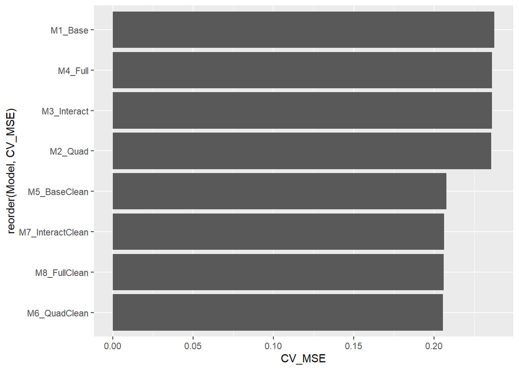

CV-MSE comparison

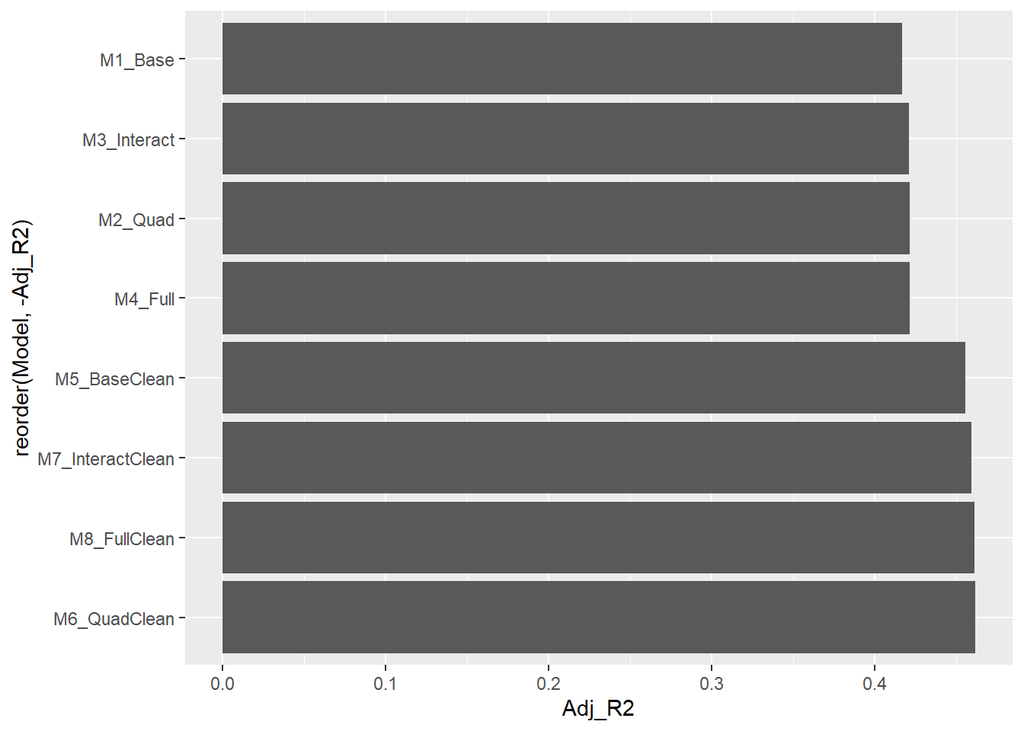

Adjusted R² comparison

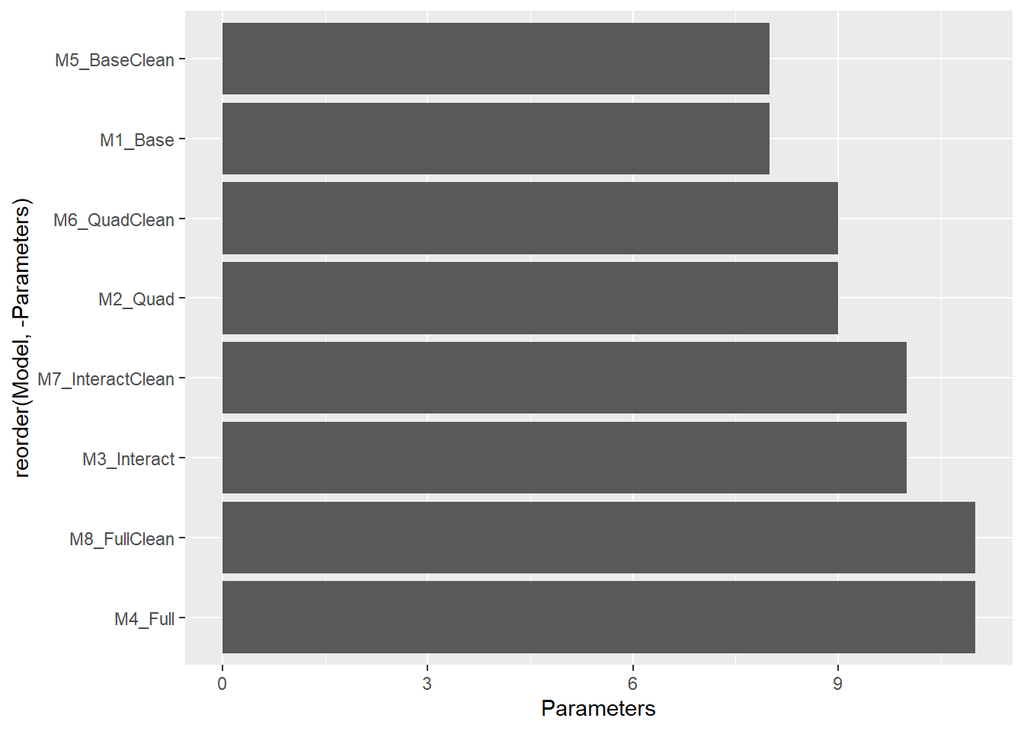

Number of parameters

Finally, we visualize the comparison metrics to help us select the best model.

```r
# We have flipped coordinate plots earlier in the document
```

## 5. Comprehensive Model Diagnostics

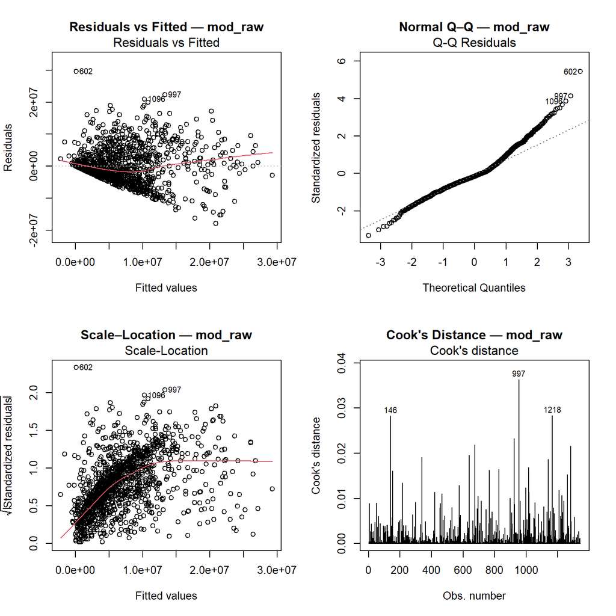

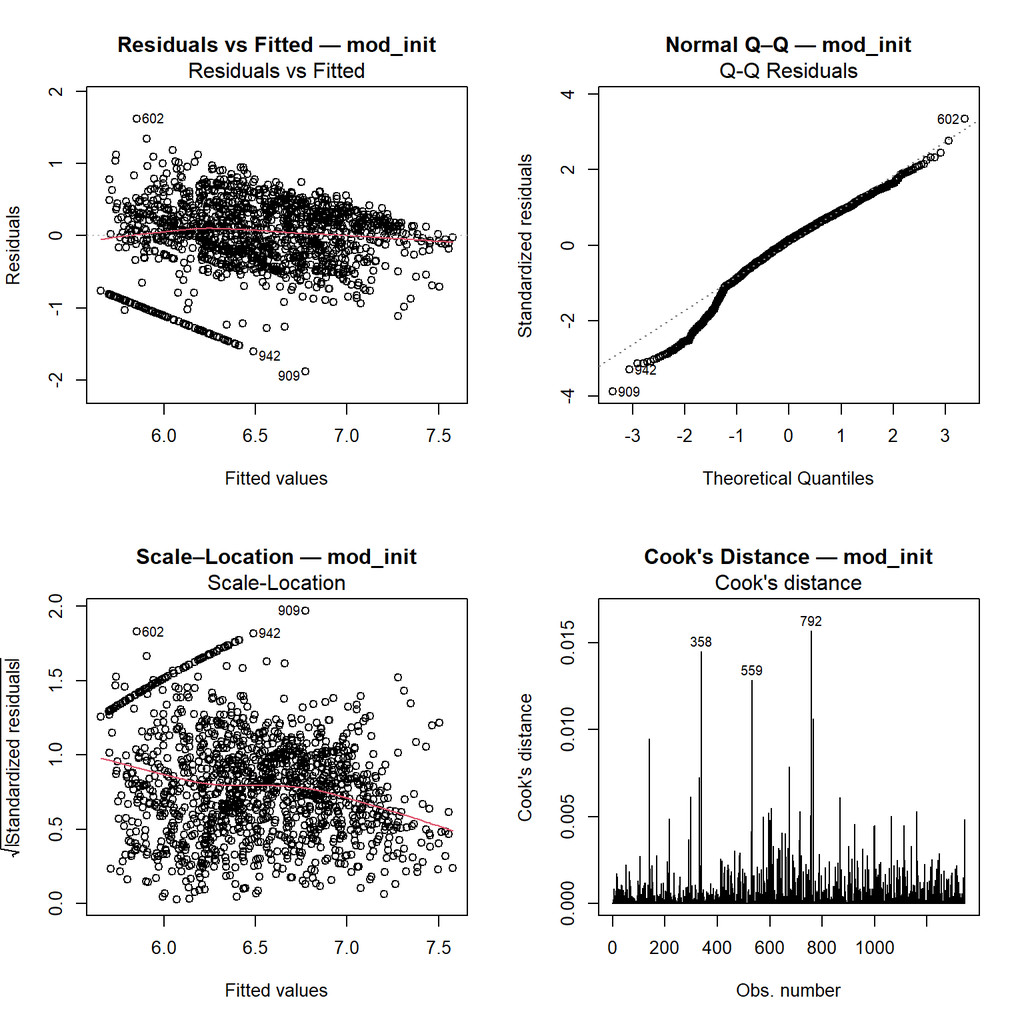

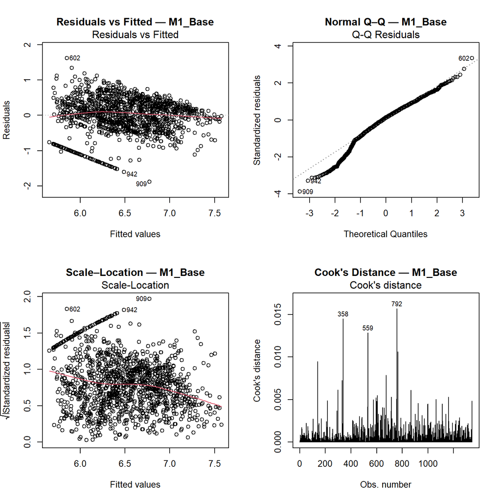

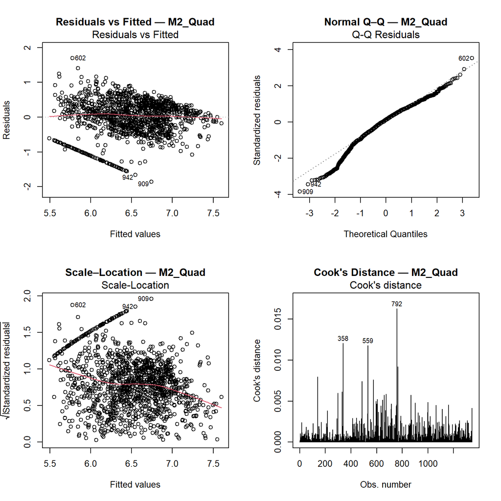

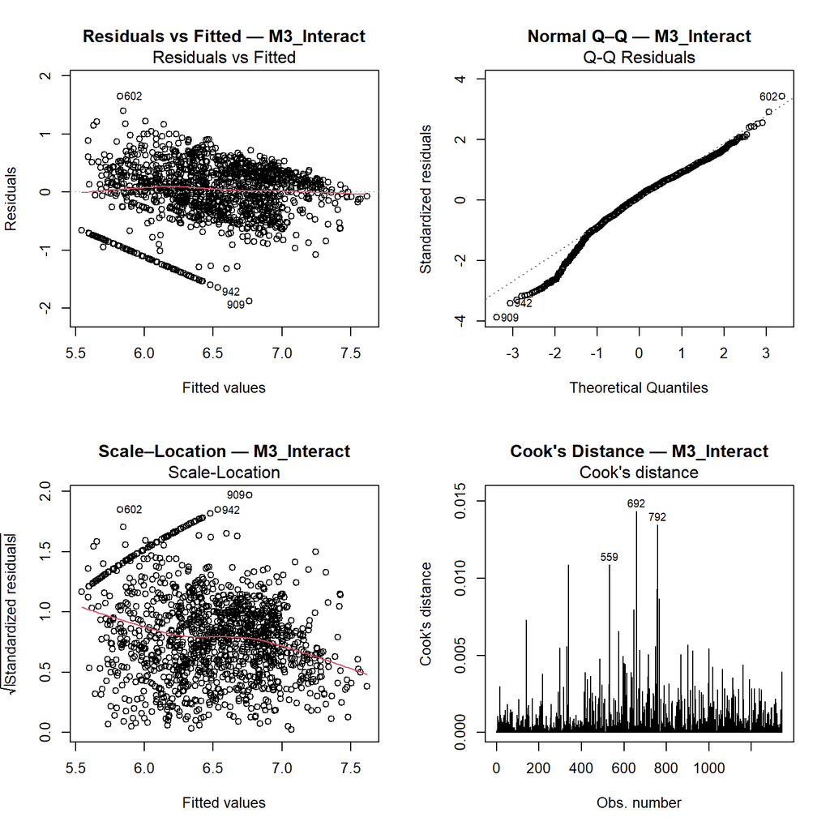

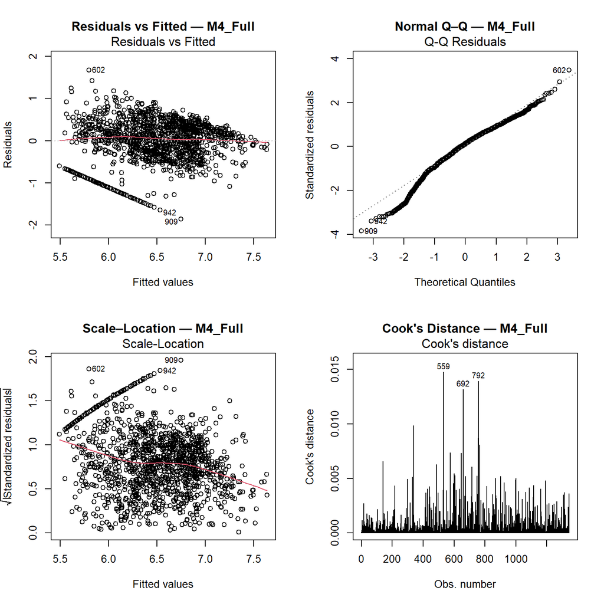

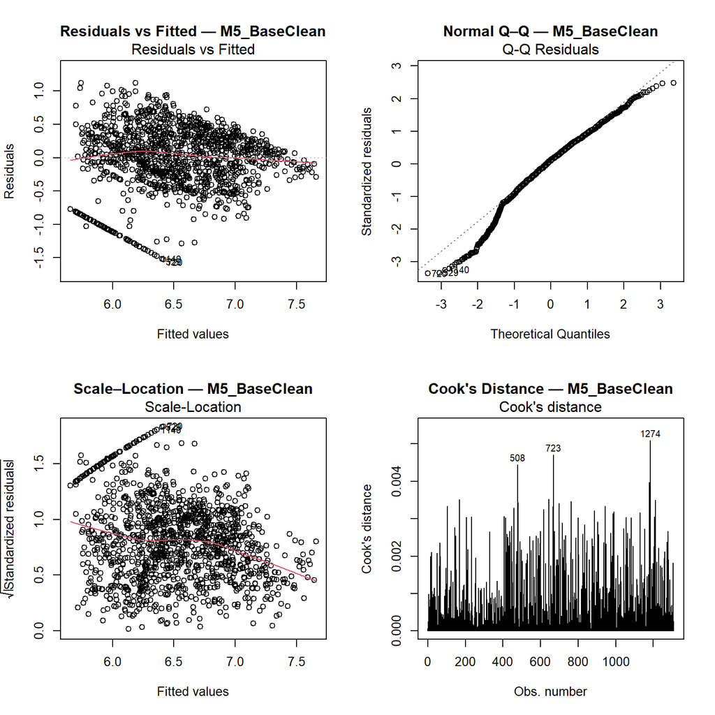

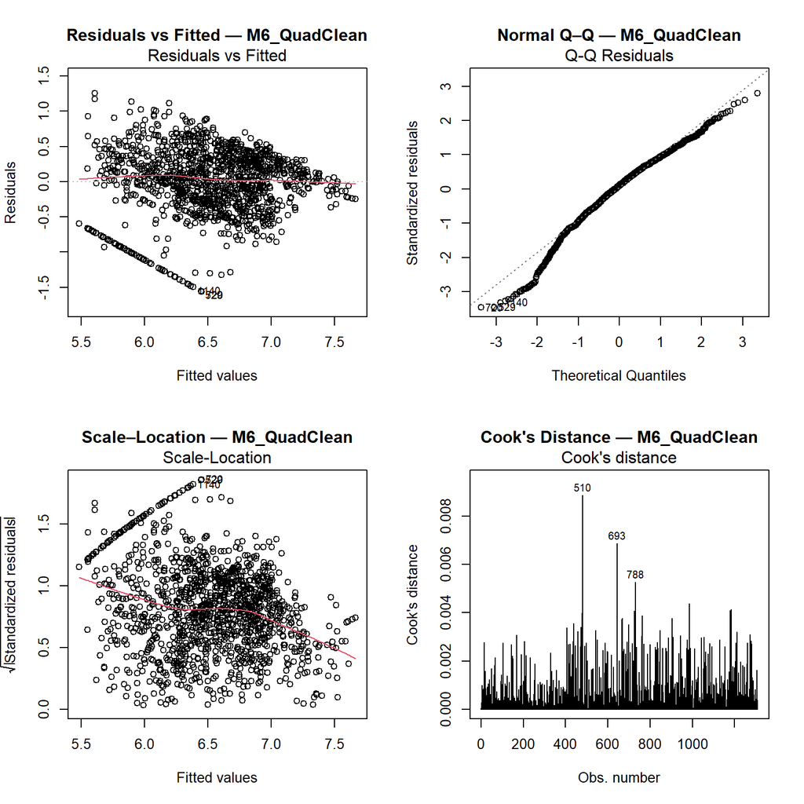

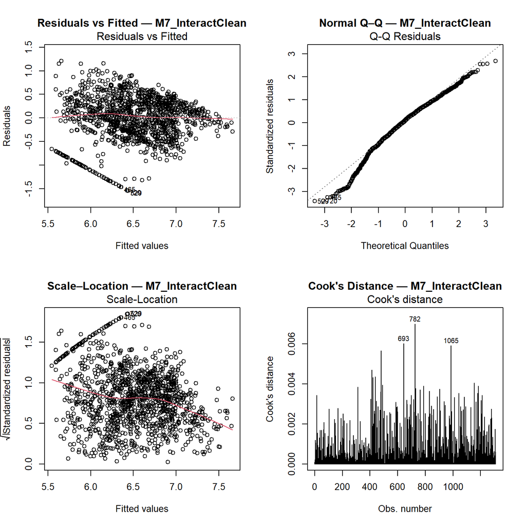

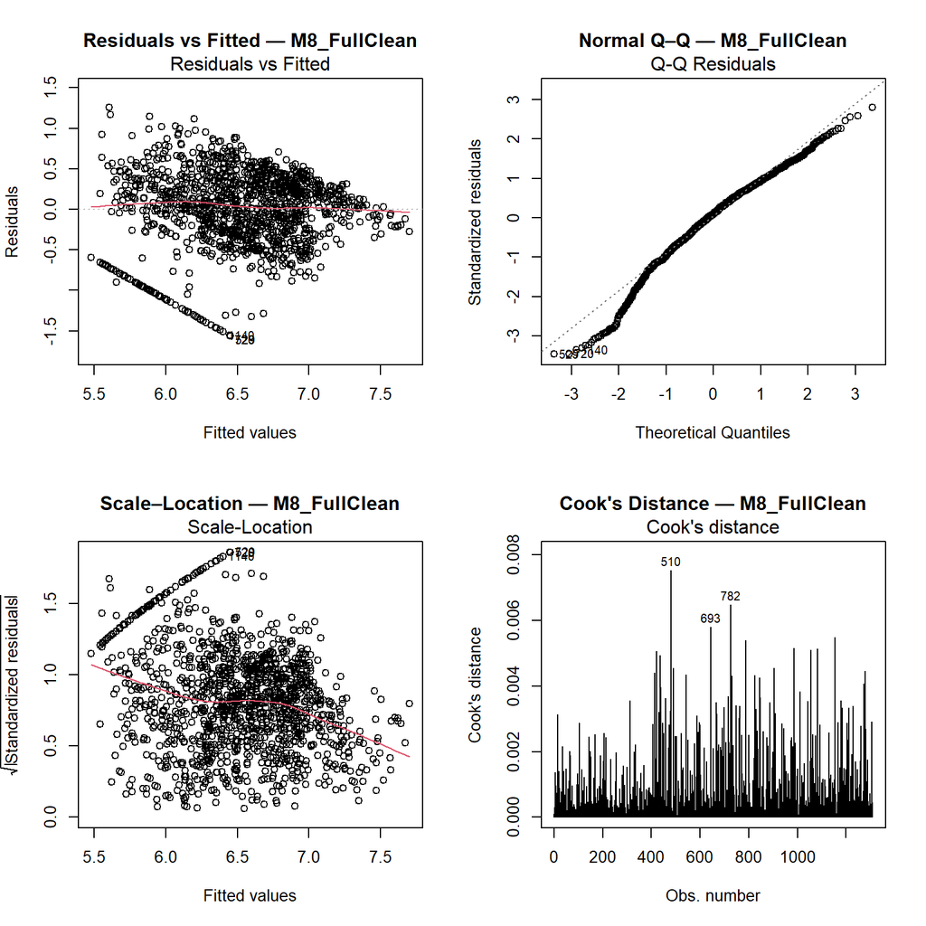

## 4.x Additional Diagnostics for Model Selection

```r
library(car)
library(ggplot2)
library(lmtest)

# 1. Fit raw (un-transformed) model
mod_raw <- lm(
  Salary ~ MP + PTS + TRB + AST + STL + BLK + PF + Play,
  data = nba
)
summary(mod_raw)
```

```
##
## Call:
## lm(formula = Salary ~ MP + PTS + TRB + AST + STL + BLK + PF +
##     Play, data = nba)
##
## Residuals:
##       Min        1Q    Median        3Q       Max
## -17879418  -3287179   -869343   2590166  29586682
##
## Coefficients:
##             Estimate Std. Error t value Pr(>|t|)
## (Intercept)  -512671     422130  -1.214 0.224777
## MP            164655      47341   3.478 0.000521 ***
## PTS           257172      63014   4.081 4.75e-05 ***
## TRB           889093     106402   8.356  < 2e-16 ***
## AST           564201     134762   4.187 3.02e-05 ***
## STL           -62157     592255  -0.105 0.916432
## BLK          -407170     536904  -0.758 0.448365
## PF          -1572820     334964  -4.695 2.93e-06 ***
## PlayYes      4514685     863866   5.226 2.01e-07 ***
## ---
## Signif. codes:  0 '***' 0.001 '**' 0.01 '*' 0.05 '.' 0.1 ' ' 1
##
## Residual standard error: 5445000 on 1337 degrees of freedom
## Multiple R-squared:  0.4693, Adjusted R-squared:  0.4661
## F-statistic: 147.8 on 8 and 1337 DF,  p-value: < 2.2e-16
```

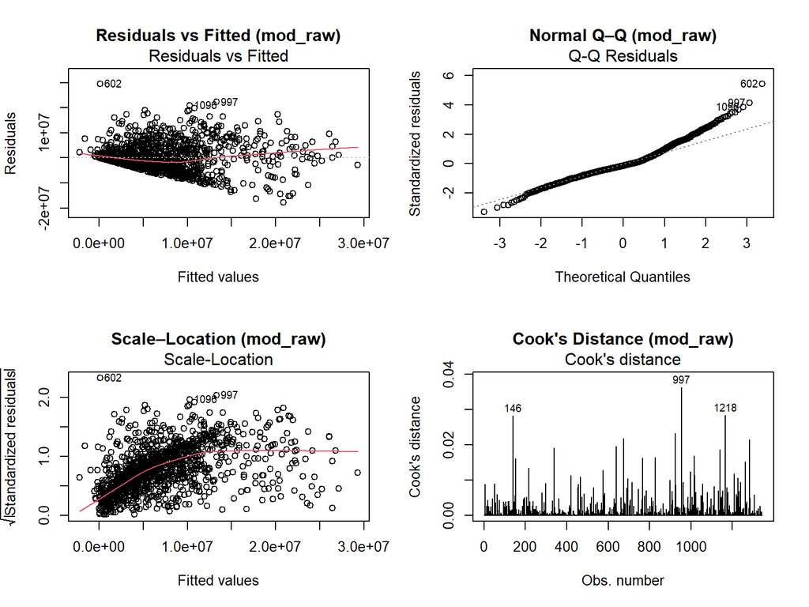

```r
# 2×2 diagnostic grid for mod_raw
par(mfrow = c(2, 2))
plot(mod_raw, which = 1, main = "Residuals vs Fitted (mod_raw)")
plot(mod_raw, which = 2, main = "Normal Q–Q (mod_raw)")
plot(mod_raw, which = 3, main = "Scale–Location (mod_raw)")
plot(mod_raw, which = 4, main = "Cook's Distance (mod_raw)")
```

```r
par(mfrow = c(1, 1))

# 2. Fit log10-transformed model
mod_init <- lm(
  log10(Salary) ~ MP_c + PTS_c + TRB_c + AST_c + STL_c + BLK_c + Play,
  data = nba
)
summary(mod_init)
```

```
##
## Call:
## lm(formula = log10(Salary) ~ MP_c + PTS_c + TRB_c + AST_c + STL_c +
##     BLK_c + Play, data = nba)
##
## Residuals:
##      Min       1Q   Median       3Q      Max
## -1.88291 -0.26054  0.06279  0.32544  1.62192
##
## Coefficients:
##              Estimate Std. Error t value Pr(>|t|)
## (Intercept)  6.498076   0.013878 468.216  < 2e-16 ***
## MP_c         0.035123   0.003936   8.925  < 2e-16 ***
## PTS_c        0.001075   0.005585   0.193    0.847
## TRB_c        0.043391   0.009148   4.743 2.33e-06 ***
## AST_c        0.018329   0.012023   1.524    0.128
## STL_c       -0.058404   0.052800  -1.106    0.269
## BLK_c       -0.026231   0.046917  -0.559    0.576
## PlayYes      0.106525   0.076502   1.392    0.164
## ---
## Signif. codes:  0 '***' 0.001 '**' 0.01 '*' 0.05 '.' 0.1 ' ' 1
##
## Residual standard error: 0.4859 on 1338 degrees of freedom
## Multiple R-squared:  0.4196, Adjusted R-squared:  0.4166
## F-statistic: 138.2 on 7 and 1338 DF,  p-value: < 2.2e-16
```

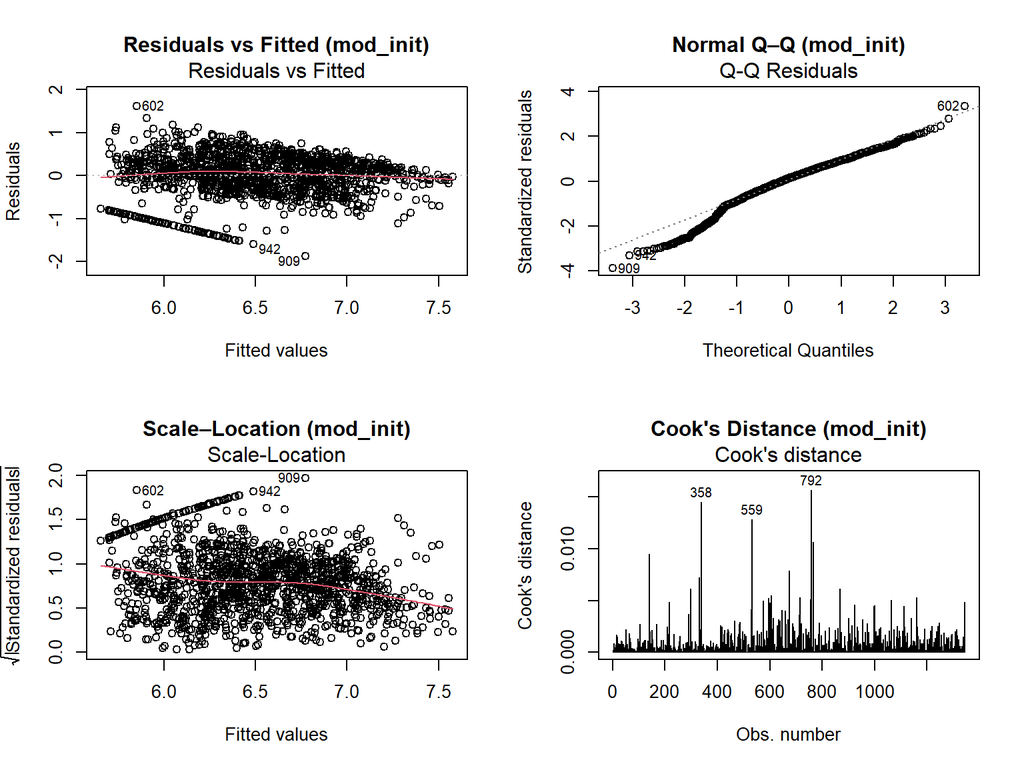

```r
# 2×2 diagnostic grid for mod_init
par(mfrow = c(2, 2))
plot(mod_init, which = 1, main = "Residuals vs Fitted (mod_init)")
plot(mod_init, which = 2, main = "Normal Q–Q (mod_init)")
plot(mod_init, which = 3, main = "Scale–Location (mod_init)")
plot(mod_init, which = 4, main = "Cook's Distance (mod_init)")
```

```r
par(mfrow = c(1, 1))

# 3. Breusch-Pagan test for heteroskedasticity
bp_raw <- bptest(mod_raw)
bp_init <- bptest(mod_init)
cat("Breusch-Pagan test p-value (raw model):", format.pval(bp_raw$p.value, digits = 3), "\n")
```

```
## Breusch-Pagan test p-value (raw model): <2e-16
```

```r
cat("Breusch-Pagan test p-value (transformed model):", format.pval(bp_init$p.value, digits = 3), "\n")
```

```
## Breusch-Pagan test p-value (transformed model): 4.8e-15
```